# fiddler crab, claw evolution

## 3D visualization of claw morphospace

Now, as a visual aid of how each mating systme is exploring the morphospace, we will plot the claw length, manus length, and dactyl length both in raw format and proportionally to body size. We will also calculate a bounding box around the two mating systems to visualize how each mating system explores the morphospace. There is no analysis, just visual representation. We would also like to disclose that we used AI to help with to code for the bounding boxes.

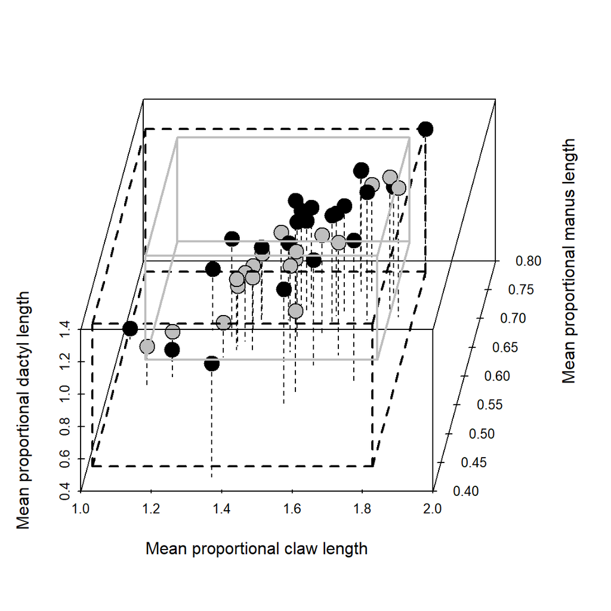

```r
## First plot, proportional sizes

s3d = scatterplot3d(
  x = uca.short$prop.claw ,
  y = uca.short$prop.manus ,
  z = uca.short$prop.out2,

  pch = 21,
  bg = c("black" , "grey")[as.numeric( as.factor( uca.short$mating ) )],
  grid = F,
  cex.symbols = 2,
  type = 'h',
  angle = 80,
  lty.hplot = 2,
  xlab = "Mean proportional claw length",
  ylab = 'Mean proportional manus length',
  zlab = "Mean proportional dactyl length",
)

add_bounding_boxes = function(data, group_var) {
  mating_systems = unique(data[[group_var]])

  for (system in mating_systems) {
    system_data <- data[data[[group_var]] == system, ]

    # Calculate min and max for each dimension
    x_range = range(system_data$prop.claw)
    y_range = range(system_data$prop.manus)
    z_range = range(system_data$prop.out2)

    # Define the 8 corners of the bounding box
    corners = matrix(c(
      x_range[1], y_range[1], z_range[1], # bottom front left
      x_range[2], y_range[1], z_range[1], # bottom front right
      x_range[2], y_range[2], z_range[1], # bottom back right
      x_range[1], y_range[2], z_range[1], # bottom back left
      x_range[1], y_range[1], z_range[2], # top front left
      x_range[2], y_range[1], z_range[2], # top front right
      x_range[2], y_range[2], z_range[2], # top back right
      x_range[1], y_range[2], z_range[2]  # top back left
    ), ncol = 3, byrow = TRUE)

    # Define which corners to connect to form the 12 edges of the box
    edges = list(
      c(1,2), c(2,3), c(3,4), c(4,1), # bottom face
      c(5,6), c(6,7), c(7,8), c(8,5), # top face
      c(1,5), c(2,6), c(3,7), c(4,8)  # vertical edges
    )

    # Draw all edges of the bounding box
    for (edge in edges) {
      s3d$points3d(
        corners[edge, ],
        type = "l",
        col = ifelse(system == "surface", "grey", "black"),
        lty = ifelse(system == "surface", 1, 2),
        lwd = 2
      )
    }
  }
}

# Add bounding boxes to the plot
add_bounding_boxes(uca.short, "mating")
```

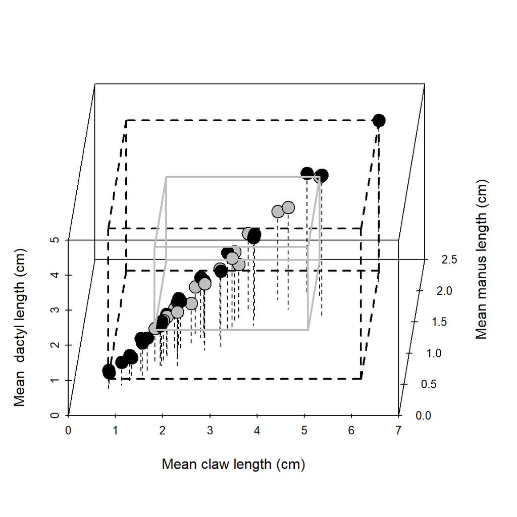

```r
## Now the second plot with raw values.

s3d = scatterplot3d(
  x = uca.short$mean.claw ,
  y = uca.short$mean.manus ,
  z = uca.short$mean.dactyl,

  pch = 21,
  bg = c("black" , "grey")[as.numeric( as.factor( uca.short$mating ) )],
  grid = F,
  cex.symbols = 2,
  type = 'h',
  angle = 80,
  lty.hplot = 2,
  xlab = "Mean claw length (cm)",
  ylab = 'Mean manus length (cm)',
  zlab = "Mean  dactyl length (cm)",
)



add_bounding_boxes = function(data, group_var) {
  mating_systems = unique(data[[group_var]])

  for (system in mating_systems) {
    system_data = data[data[[group_var]] == system, ]

    # Calculate min and max for each dimension
    x_range = range(system_data$mean.claw)
    y_range = range(system_data$mean.manus)
    z_range = range(system_data$mean.dactyl)

    # Define the 8 corners of the bounding box
    corners = matrix(c(
      x_range[1], y_range[1], z_range[1], # bottom front left
      x_range[2], y_range[1], z_range[1], # bottom front right
      x_range[2], y_range[2], z_range[1], # bottom back right
      x_range[1], y_range[2], z_range[1], # bottom back left
      x_range[1], y_range[1], z_range[2], # top front left
      x_range[2], y_range[1], z_range[2], # top front right
      x_range[2], y_range[2], z_range[2], # top back right
      x_range[1], y_range[2], z_range[2]  # top back left
    ), ncol = 3, byrow = TRUE)

    # Define which corners to connect to form the 12 edges of the box
    edges = list(
      c(1,2), c(2,3), c(3,4), c(4,1), # bottom face
      c(5,6), c(6,7), c(7,8), c(8,5), # top face
      c(1,5), c(2,6), c(3,7), c(4,8)  # vertical edges
    )

    # Draw all edges of the bounding box
    for (edge in edges) {
      s3d$points3d(
        corners[edge, ],
        type = "l",
        col = ifelse(system == "surface", "grey", "black"),
        lty = ifelse(system == "surface", 1, 2),
        lwd = 2
      )
    }
  }
}

# Add bounding boxes to the plot
add_bounding_boxes(uca.short, "mating")
```

## Session Info

```r
sessionInfo() %>% pander
```

**R version 4.5.0 (2025-04-11 ucrt)**

**Platform:** x86_64-w64-mingw32/x64

**locale:** *LC_COLLATE=Portuguese_Brazil.utf8*, *LC_CTYPE=Portuguese_Brazil.utf8*, *LC_MONETARY=Portuguese_Brazil.utf8*, *LC_NUMERIC=C* and *LC_TIME=Portuguese_Brazil.utf8*

**attached base packages:** *stats4*, *stats*, *graphics*, *grDevices*, *utils*, *datasets*, *methods* and *base*

**other attached packages:** *scatterplot3d(v.0.3-44)*, *pander(v.0.6.6)*, *sp(v.2.2-0)*, *RColorBrewer(v.1.1-3)*, *latticeExtra(v.0.6-30)*, *lattice(v.0.22-6)*, *corncob(v.0.4.2)*, *performance(v.0.14.0)*, *scales(v.1.4.0)*, *viridis(v.0.6.5)*, *viridisLite(v.0.4.2)*, *ratematrix(v.1.2.4)*, *phylolm(v.2.6.5)*, *ellipse(v.0.5.0)*, *vioplot(v.0.5.1)*, *zoo(v.1.8-14)*, *sm(v.2.2-6.0)*, *mvMORPH(v.1.2.1)*, *subplex(v.1.9)*, *corpcor(v.1.6.10)*, *bbmle(v.1.0.25.1)*, *lubridate(v.1.9.4)*, *forcats(v.1.0.0)*, *stringr(v.1.5.1)*, *dplyr(v.1.1.4)*, *purrr(v.1.0.4)*, *readr(v.2.1.5)*, *tidyr(v.1.3.1)*, *tibble(v.3.2.1)*, *ggplot2(v.3.5.2)*, *tidyverse(v.2.0.0)*, *geiger(v.2.0.11)*, *phytools(v.2.4-4)*, *maps(v.3.4.2.1)* and *ape(v.5.8-1)*